# Introduction

This data set contains 13 attributes that are used as predictors for heart attacks in patients. Some of these attributes are age, sex, chest pain, resting blood pressure, cholestoral, and some others. The target column uses binary classification to see if someone is at risk for heart disease. 0=no risk, 1=more risk to a heart attack.

I am going to use k-means clustering as an unsupervised learning model method to identify the at risk groups. I am also going to be using a few supervised learning methods such as k-nearest neighbors and logistic regression to make predictions on if patients have an increase risk of a heart attack or not.

I will then compare the unsupervised and supervised models together to determine which has performed better and if there are any limitations with either of the models.

I will also do some exploratory data analysis to see if I visually find any patterns in the data that can provide some information on the risk factors to heart attacks.

According to the Centers for Disease Control and Prevention (CDC, n.d.), in the United States, heart disease is the leading cause of death for both men and women. Heart Disease accounts for every 1 and 5 deaths. It is important to look at the factors that put individuals at risk for heart disease so that we can work to prevent these risk factors.

## Data

```python
# importing necessary libraries
import numpy as np   #Linear algera Library
import pandas as pd
import matplotlib.pyplot as plt  #to plot graphs
import seaborn as sns
from sklearn.model_selection import train_test_split
from sklearn.linear_model import LogisticRegression
from sklearn.metrics import classification_report,confusion_matrix
import math
from sklearn import metrics
from sklearn.neighbors import KNeighborsClassifier
from sklearn.model_selection import train_test_split, GridSearchCV
from sklearn.metrics import accuracy_score
from sklearn.cluster import KMeans
```

```python
# importing dataset
heart=pd.read_csv("heart.csv")

heart.head()
```

|  | age | sex | cp | trestbps | chol | fbs | restecg | thalach | exang | oldpeak | slope | ca | thal | target |
| --- | --- | --- | --- | --- | --- | --- | --- | --- | --- | --- | --- | --- | --- | --- |
| 0 | 63 | 1 | 3 | 145 | 233 | 1 | 0 | 150 | 0 | 2.3 | 0 | 0 | 1 | 1 |
| 1 | 37 | 1 | 2 | 130 | 250 | 0 | 1 | 187 | 0 | 3.5 | 0 | 0 | 2 | 1 |
| 2 | 41 | 0 | 1 | 130 | 204 | 0 | 0 | 172 | 0 | 1.4 | 2 | 0 | 2 | 1 |
| 3 | 56 | 1 | 1 | 120 | 236 | 0 | 1 | 178 | 0 | 0.8 | 2 | 0 | 2 | 1 |
| 4 | 57 | 0 | 0 | 120 | 354 | 0 | 1 | 163 | 1 | 0.6 | 2 | 0 | 2 | 1 |

```python
#description of data
print(len(heart))
print(heart.columns)
print(len(heart.columns))
print(heart.dtypes)
```

```
303
Index(['age', 'sex', 'cp', 'trestbps', 'chol', 'fbs', 'restecg', 'thalach',
       'exang', 'oldpeak', 'slope', 'ca', 'thal', 'target'],
      dtype='object')
14
age           int64
sex           int64
cp            int64
trestbps      int64
chol          int64
fbs           int64
restecg       int64
thalach       int64
exang         int64
oldpeak     float64
slope         int64
ca            int64
thal          int64
target        int64
dtype: object
```

```python
heart.describe()
```

|  | age | sex | cp | trestbps | chol | fbs | restecg | thalach | exang | oldpeak | slope | ca | thal | target |
| --- | --- | --- | --- | --- | --- | --- | --- | --- | --- | --- | --- | --- | --- | --- |
| count | 303.000000 | 303.000000 | 303.000000 | 303.000000 | 303.000000 | 303.000000 | 303.000000 | 303.000000 | 303.000000 | 303.000000 | 303.000000 | 303.000000 | 303.000000 | 303.000000 |
| mean | 54.366337 | 0.683168 | 0.966997 | 131.623762 | 246.264026 | 0.148515 | 0.528053 | 149.646865 | 0.326733 | 1.039604 | 1.399340 | 0.729373 | 2.313531 | 0.544554 |
| std | 9.082101 | 0.466011 | 1.032052 | 17.538143 | 51.830751 | 0.356198 | 0.525860 | 22.905161 | 0.469794 | 1.161075 | 0.616226 | 1.022606 | 0.612277 | 0.498835 |
| min | 29.000000 | 0.000000 | 0.000000 | 94.000000 | 126.000000 | 0.000000 | 0.000000 | 71.000000 | 0.000000 | 0.000000 | 0.000000 | 0.000000 | 0.000000 | 0.000000 |
| 25% | 47.500000 | 0.000000 | 0.000000 | 120.000000 | 211.000000 | 0.000000 | 0.000000 | 133.500000 | 0.000000 | 0.000000 | 1.000000 | 0.000000 | 2.000000 | 0.000000 |
| 50% | 55.000000 | 1.000000 | 1.000000 | 130.000000 | 240.000000 | 0.000000 | 1.000000 | 153.000000 | 0.000000 | 0.800000 | 1.000000 | 0.000000 | 2.000000 | 1.000000 |
| 75% | 61.000000 | 1.000000 | 2.000000 | 140.000000 | 274.500000 | 0.000000 | 1.000000 | 166.000000 | 1.000000 | 1.600000 | 2.000000 | 1.000000 | 3.000000 | 1.000000 |
| max | 77.000000 | 1.000000 | 3.000000 | 200.000000 | 564.000000 | 1.000000 | 2.000000 | 202.000000 | 1.000000 | 6.200000 | 2.000000 | 4.000000 | 3.000000 | 1.000000 |

```python
print(heart['target'].describe())
```

```
count    303.000000
mean       0.544554
std        0.498835
min        0.000000
25%        0.000000
50%        1.000000
75%        1.000000
max        1.000000
Name: target, dtype: float64
```

# Exploratory Data Analysis (EDA)

This data has 303 samples and 13 feature or factors with one target column with binary classification of whether a person is at risk of a heart attack or not.

## Data Cleaning

After gathering some information on this data set I am going to clean the data to prepare for analysis and modeling.

```python
# starting my looking at null values in the data set
heart.isna().sum()
```

```
age         0
sex         0
cp          0
trestbps    0
chol        0
fbs         0
restecg     0
thalach     0
exang       0
oldpeak     0
slope       0
ca          0
thal        0
target      0
dtype: int64
```

```python
# there are no null values in the data set so I will be able to leave the data as is
```

## EDA

I am going to look at the features of this dataset in more detail.

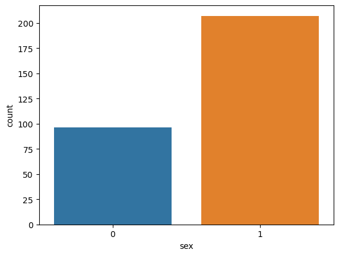

```python
# distribution of sex in the data set
sns.countplot(data=heart, x='sex')
```

The feature sex is very umbalanced, there are about twice as many males in the data as females.

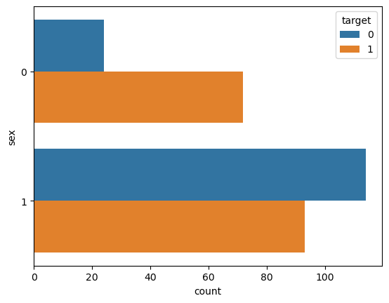

```python
# comparing sex to heart attack risk
sns.countplot(y='sex', data=heart, hue='target')
```

This graphic shows the target response is more balanced because the proportion of women that are at risk for a heart attack (target=1) is higher than the proportion of men that are at risk for a heart attack.

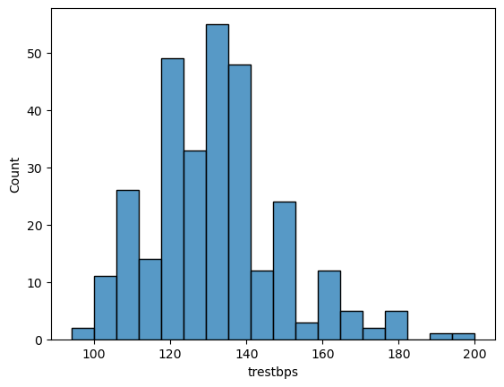

```python
# looking at feature of resting blood pressure to risk of heart attack
sns.histplot(x='trestbps', data=heart)
```

```python
heart['trestbps'].describe()
```

```
count    303.000000
mean     131.623762
std       17.538143
min       94.000000
25%      120.000000
50%      130.000000
75%      140.000000
max      200.000000
Name: trestbps, dtype: float64
```

This graph shows the distribution of resting blood pressure values which looks to be higher than what a doctor would want a person to be at of 120 mmHg. Looking at the mean value for resting blood pressure of 131.62 mmHg we can confirm the majority of people have a higher blood pressure level than the "normal range".

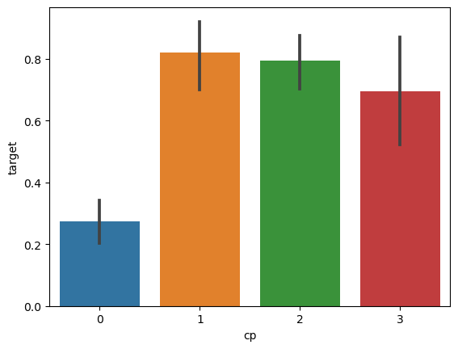

```python
# looking at the feature chest pain level (cp)
# there are 4 values for this feature on a rating scale from 0-3, 0=no pain, 3=most painful
sns.barplot(x='cp', y='target', data=heart)
```

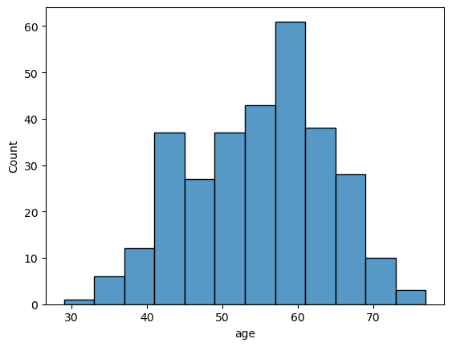

```python
# age distribution for data set
sns.histplot(x="age", data=heart)
```

```python
heart['age'].describe()
```

```
count    303.000000
mean      54.366337
std        9.082101
min       29.000000
25%       47.500000
50%       55.000000
75%       61.000000
max       77.000000
Name: age, dtype: float64
```

The average age is about 54 years old with the youngest age being 29 years old and the oldest 77 years old. This dataset encapsulates older individuals.

Since age can play a huge factor into risk for a heart attack I am going to explore this feature in a bit more detail.

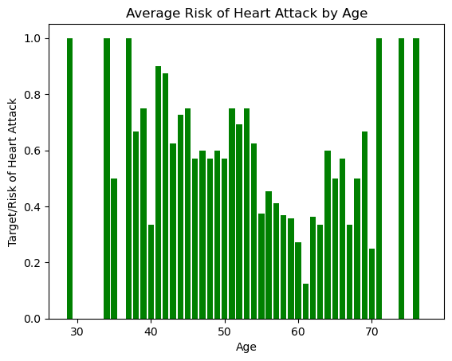

```python
# looking at the distribution of risk of heart attack by age using average/mean values
age=heart.groupby('age')['target'].mean()
plt.bar(age.index, age.values, color="green")

# labeling
plt.xlabel("Age")
plt.ylabel("Target/Risk of Heart Attack")
plt.title("Average Risk of Heart Attack by Age")

plt.show()
```

There does not seem to be much correlation between the age of an individual and if they are more at risk for a heart attack, other features may be able to explain risk better than age.

Looking at correlations between features can help me see if there is any collinearity in the data set. This will also help visualize which features are most correlated with the target, risk of heart attack.

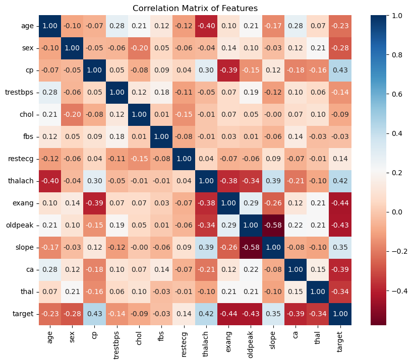

```python
# Create correlation matrix
correlation_matrix = heart.corr()

# Create a larger figure
fig, ax = plt.subplots(figsize=(10, 8))

# Create heatmap
sns.heatmap(correlation_matrix, annot=True, fmt=".2f", cmap="RdBu", ax=ax)

# Set title and display the heatmap
plt.title("Correlation Matrix of Features")
plt.show()
```

Only two features show correlation with each other above 0.5 in the positive or negative direction. This is the feature "oldpeak" which is ST depression induced by exercise relative to rest and "slope" which is the slop of the peak exercise ST segment. This makes sense on how these features would show some correlation because they are both measuring ST segment which is from electrocardiogram data measuring the electrical signals from the heart and someone's heart beat.

Since the correlation is still only at -0.58 I do not think I need to adjust this data set to prevent colliniarity. I do not think colliniarity will affect my modeling based on this correlation matrix.

```python
# checking for outliers
heart.describe()
```

|  | age | sex | cp | trestbps | chol | fbs | restecg | thalach | exang | oldpeak | slope | ca | thal | target |
| --- | --- | --- | --- | --- | --- | --- | --- | --- | --- | --- | --- | --- | --- | --- |
| count | 303.000000 | 303.000000 | 303.000000 | 303.000000 | 303.000000 | 303.000000 | 303.000000 | 303.000000 | 303.000000 | 303.000000 | 303.000000 | 303.000000 | 303.000000 | 303.000000 |
| mean | 54.366337 | 0.683168 | 0.966997 | 131.623762 | 246.264026 | 0.148515 | 0.528053 | 149.646865 | 0.326733 | 1.039604 | 1.399340 | 0.729373 | 2.313531 | 0.544554 |
| std | 9.082101 | 0.466011 | 1.032052 | 17.538143 | 51.830751 | 0.356198 | 0.525860 | 22.905161 | 0.469794 | 1.161075 | 0.616226 | 1.022606 | 0.612277 | 0.498835 |
| min | 29.000000 | 0.000000 | 0.000000 | 94.000000 | 126.000000 | 0.000000 | 0.000000 | 71.000000 | 0.000000 | 0.000000 | 0.000000 | 0.000000 | 0.000000 | 0.000000 |
| 25% | 47.500000 | 0.000000 | 0.000000 | 120.000000 | 211.000000 | 0.000000 | 0.000000 | 133.500000 | 0.000000 | 0.000000 | 1.000000 | 0.000000 | 2.000000 | 0.000000 |
| 50% | 55.000000 | 1.000000 | 1.000000 | 130.000000 | 240.000000 | 0.000000 | 1.000000 | 153.000000 | 0.000000 | 0.800000 | 1.000000 | 0.000000 | 2.000000 | 1.000000 |
| 75% | 61.000000 | 1.000000 | 2.000000 | 140.000000 | 274.500000 | 0.000000 | 1.000000 | 166.000000 | 1.000000 | 1.600000 | 2.000000 | 1.000000 | 3.000000 | 1.000000 |
| max | 77.000000 | 1.000000 | 3.000000 | 200.000000 | 564.000000 | 1.000000 | 2.000000 | 202.000000 | 1.000000 | 6.200000 | 2.000000 | 4.000000 | 3.000000 | 1.000000 |

Looking at a summary description of the data is a good way to visually inspect for outliers. I checked the mean values as well as the minimum and max values of each feature to see if anything is out of range of what to be expected. There do not look to be any outliers in this data set so nothing will need to be removed.

# Modeling

## Unsupervised Learning, K-Means Clustering

### Splitting data into train and test sets

```python
# setting X variable
X = heart[['age', 'sex', 'cp', 'trestbps', 'chol', 'fbs', 'restecg', 'thalach', 'exang', 'oldpeak', 'slope', 'ca', 'thal']]

# setting target
y = heart['target'].values

# splitting data
X_train, X_test, y_train, y_test = train_test_split(X, y, test_size=0.20, random_state=42)

# checking split
print(len(X_train))
print(len(X_test))
```

```
242
61
```

I am going to fit a k-means clustering model to this data set to see how an unsupervised learning model performs. I am first going to create a cross-validation to see which hyperparameters perform best with this model.

```python
# CV
model=KMeans()
# creating hyperparameters grid
param_grid = {'n_clusters': [2, 3, 4, 5]}

# grid-search
grid_search=GridSearchCV(model, param_grid)

grid_search.fit(X_train, y_train)

# best number of clusters
best_params = grid_search.best_params_['n_clusters']

print(best_params)
```

```
5
```

Even though this is a binary classification data set 5 clusters may still be the best fit. I am going to run k-means clustering with 2 clusters as well as 5.

### K-means clustering, clusters=5

```python
# creating k means clustering with 5 clusters
kmeans5 = KMeans(n_clusters=5)

# fitting the model
kmeans5.fit(X_train, y_train)

# prediction
y_pred_kmeans_5 = kmeans5.predict(X_test)
```

### K-means clustering, clusters=2

```python
# creating k means clustering with 2 clusters
kmeans2 = KMeans(n_clusters=2)

# fitting the model
kmeans2.fit(X_train, y_train)

# prediction
y_pred_kmeans_2 = kmeans2.predict(X_test)
```

## Supervised Learning, Logistic Regression and K-Nearest Neighbors

The data is already split into training and test sets. I am going to perform logistic regression which is a good method for binary class classification and also k-nearest neighbors.

I am going to perform a cross-validation to see what hyperparameters perform best for K-Nearest Neighbors

### Logistic Regression

```python
# creating model
LogReg=LogisticRegression(max_iter=10000)

# fitting the model
LogReg.fit(X_train, y_train)

# predicting
y_pred_LogReg = LogReg.predict(X_test)
```

### K-Nearest Neighbors

```python
# creating a cross-validation for hyperparameters
# CV
knn=KNeighborsClassifier()
# creating hyperparameters grid
param_grid = {'n_neighbors': [2, 3, 5, 7], # Different values for k
             'weights': ['uniform', 'distance'], # Weighting scheme for neighbors
             'p': [1, 2] # distance metric (1: Manhattan, 2: Euclidean)
             }

# grid-search
grid_search=GridSearchCV(knn, param_grid, cv=5)

grid_search.fit(X_train, y_train)

# best number of clusters
best = grid_search.best_params_

print(best)
```

```
{'n_neighbors': 7, 'p': 1, 'weights': 'distance'}
```

```python
# using 7 neighbors, distance for weighting scheme and manhattan distance for distance metric
knn=KNeighborsClassifier(n_neighbors=7, weights='distance', p=1)

# fitting model
knn_model=knn.fit(X_train, y_train)

# predictions
y_pred_knn = knn.predict(X_test)
```

# Results and Analysis

I am going to be using acuracy, precision, recall, f1-score, mean absolute value, mean squared value, root mean squared value, and confusion matrices to determine which model performed the best.

## Acuracy Scores

```python
# K-means clustering, clusters=5
k_means_5_accuracy = accuracy_score(y_test, y_pred_kmeans_5)
print("Accuracy of K-means clustering with 5 clusters:", k_means_5_accuracy)

# K-means clustering, clusters=2
k_means_2_accuracy = accuracy_score(y_test, y_pred_kmeans_2)
print("Accuracy of K-means clustering with 2 clusters:", k_means_2_accuracy)

# Logistic Regression
logreg_accuracy = accuracy_score(y_test, y_pred_LogReg)
print("Accuracy of Logistic Regression Model:", logreg_accuracy)

# K-nearest Neighbors
knn_accuracy = accuracy_score(y_test, y_pred_knn)
print("Accuracy of K-nearest Neighbors:", knn_accuracy)
```

```
Accuracy of K-means clustering with 5 clusters: 0.2786885245901639
Accuracy of K-means clustering with 2 clusters: 0.6229508196721312
Accuracy of Logistic Regression Model: 0.8852459016393442
Accuracy of K-nearest Neighbors: 0.7049180327868853
```

Based on Accuracy, Supervised learning models perform a large amount better than unsupervised learning models, specifically logistic regression performed will with an accuracy of about 88.5%.

## Precision, Recall, and F1-score

```python
# classification report for K-means clustering, clusters=5
print(classification_report(y_test,y_pred_kmeans_5))
print("\n")
```

```
              precision    recall  f1-score   support

           0       0.70      0.24      0.36        29
           1       0.59      0.31      0.41        32
           2       0.00      0.00      0.00         0
           3       0.00      0.00      0.00         0
           4       0.00      0.00      0.00         0

    accuracy                           0.28        61
   macro avg       0.26      0.11      0.15        61
weighted avg       0.64      0.28      0.38        61
```

```python
# classification report for K-means clustering, clusters=2
print(classification_report(y_test,y_pred_kmeans_2))
print("\n")
```

```
              precision    recall  f1-score   support

           0       0.64      0.48      0.55        29
           1       0.62      0.75      0.68        32

    accuracy                           0.62        61
   macro avg       0.63      0.62      0.61        61
weighted avg       0.63      0.62      0.62        61
```

```python
# classificaiton report for Logistic Regression
print(classification_report(y_test,y_pred_LogReg))
print("\n")
```

```
              precision    recall  f1-score   support

           0       0.89      0.86      0.88        29
           1       0.88      0.91      0.89        32

    accuracy                           0.89        61
   macro avg       0.89      0.88      0.88        61
weighted avg       0.89      0.89      0.89        61
```

```python
# classificaiton report for K-nearest neighbors
print(classification_report(y_test,y_pred_knn))
print("\n")
```

```
              precision    recall  f1-score   support

           0       0.68      0.72      0.70        29
           1       0.73      0.69      0.71        32

    accuracy                           0.70        61
   macro avg       0.71      0.71      0.70        61
weighted avg       0.71      0.70      0.71        61
```

The precision, recall and f1-score values show the same results as the accuracy score. The Logistic Regression model still performs the best in all three of these metrics. The unsupervised machine learning models do not perform well at all based on these metrics. The precision of the unsupervised models is about the same as k-nearest neighbors but since the accuracy is so low I would expect the variance to be very high for the unsupervised models still.

## Mean Absolute Value, RMSE, and MSE

```python
#MSE, RMSE, and mean absolute value metrics

# K-means clustering, clusters=5
print('Clusters=5, Mean Abs value:' ,metrics.mean_absolute_error(y_test,y_pred_kmeans_5))
print('Clusters=5, Mean squared value:',metrics.mean_squared_error(y_test,y_pred_kmeans_5))
print('Clusters=5, root mean squared error value:',math.sqrt(metrics.mean_squared_error(y_test,y_pred_kmeans_5)))

# K-means clustering, clusters=2
print('Clusters=2, Mean Abs value:' ,metrics.mean_absolute_error(y_test,y_pred_kmeans_2))
print('Clusters=2, Mean squared value:',metrics.mean_squared_error(y_test,y_pred_kmeans_2))
print('Clusters=2, root mean squared error value:',math.sqrt(metrics.mean_squared_error(y_test,y_pred_kmeans_2)))

# Logistic Regression
print('Logistic Regression Mean Abs value:' ,metrics.mean_absolute_error(y_test,y_pred_LogReg))
print('Logistic Regression Mean squared value:',metrics.mean_squared_error(y_test,y_pred_LogReg))
print('Logistic Regression root mean squared error value:',math.sqrt(metrics.mean_squared_error(y_test,y_pred_LogReg)))

# K-nearest Neighbors
print('KNN Mean Abs value:' ,metrics.mean_absolute_error(y_test,y_pred_knn))
print('KNN Mean squared value:',metrics.mean_squared_error(y_test,y_pred_knn))
print('KNN root mean squared error value:',math.sqrt(metrics.mean_squared_error(y_test,y_pred_knn)))
```

```
Clusters=5, Mean Abs value: 1.8360655737704918
Clusters=5, Mean squared value: 5.344262295081967
Clusters=5, root mean squared error value: 2.311766055439427
Clusters=2, Mean Abs value: 0.3770491803278688
Clusters=2, Mean squared value: 0.3770491803278688
Clusters=2, root mean squared error value: 0.6140433049287882
Logistic Regression Mean Abs value: 0.11475409836065574
Logistic Regression Mean squared value: 0.11475409836065574
Logistic Regression root mean squared error value: 0.3387537429470791
KNN Mean Abs value: 0.29508196721311475
KNN Mean squared value: 0.29508196721311475
KNN root mean squared error value: 0.5432144762551112
```

## Confusion Matrix Heatmaps

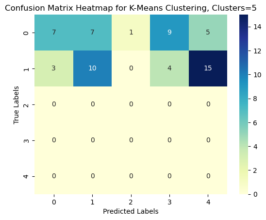

```python
# K-means clustering, clusters=5
cm_5_clusters=confusion_matrix(y_test, y_pred_kmeans_5)
sns.heatmap(cm_5_clusters, annot=True, cmap="YlGnBu")
plt.xlabel("Predicted Labels")
plt.ylabel("True Labels")
plt.title("Confusion Matrix Heatmap for K-Means Clustering, Clusters=5")
plt.show()
```

A confusion matrix for 5 clusters is not interpretable. This can be dismissed

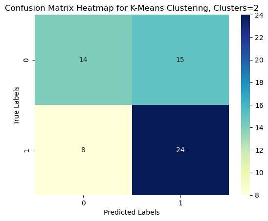

```python
# K-means clustering, clusters=2
cm_2_clusters=confusion_matrix(y_test, y_pred_kmeans_2)
sns.heatmap(cm_2_clusters, annot=True, cmap="YlGnBu")
plt.xlabel("Predicted Labels")
plt.ylabel("True Labels")
plt.title("Confusion Matrix Heatmap for K-Means Clustering, Clusters=2")
plt.show()
```

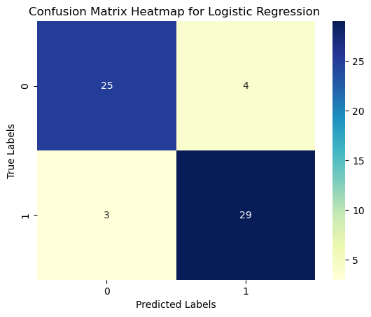

```python
# Logistic Regression
cm_logreg=confusion_matrix(y_test, y_pred_LogReg)
sns.heatmap(cm_logreg, annot=True, cmap="YlGnBu")
plt.xlabel("Predicted Labels")
plt.ylabel("True Labels")
plt.title("Confusion Matrix Heatmap for Logistic Regression ")
plt.show()
```

This confusion matrix shows how many more classifications the Logisitc Regression model got correct in comparision to the other models.

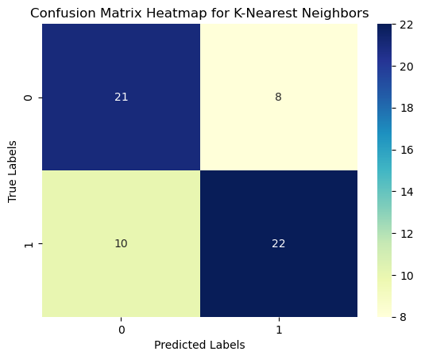

```python
# K-nearest Neighbors
cm_knn=confusion_matrix(y_test, y_pred_knn)
sns.heatmap(cm_knn, annot=True, cmap="YlGnBu")
plt.xlabel("Predicted Labels")
plt.ylabel("True Labels")
plt.title("Confusion Matrix Heatmap for K-Nearest Neighbors")
plt.show()
```

This confusion matrix shows that the KNN model performs better than the unsupervised learning methods but not as well as the Logistic Regresion model.

# Conclusion

Summary of Results Overall, the Logistic Regression model performed a lot better than the k-means clustering model with 2 clusters and with 5 cluster and also performed better than the k-nearest neighbors model in all measures. Supervised learning performed better than unsupervised learning for this dataset. This could be because there is binary classification of a yes or no, increased risk of heart attack or no increased risk of heart attack. It seems like unsupervised learning models, especially k-means clustering is limited with this type of classification.

This project could look at other unsupervised models for further investigation. I do not think a different supervised model would perform better than logistic regression because it performed decently well. Unsupervised modeling may just not work well with this data set, it didn't need PCA for dimensionality reduction which is a main task for unsupervised learning. There are probably other data sets that perform better with k-means clustering methods, probably data sets that do not have binary classification but a few different groups of similar data points with similar attributes.

## References

Centers for Disease Control and Prevention. (n.d.). Heart disease facts. Retrieved from https://www.cdc.gov/heartdisease/facts.htm

Nareshbhat. (2021). Health care Data set on Heart Attack Possibility. Retrieved from Kaggle: [https://www.kaggle.com/datasets/nareshbhat/health-care-data-set-on-heart-attack-possibility?select=heart.csv]